# Final Quiz

Beatriz Wahle

2024-11-17

### Telecom Data Churn

```r
# All Libraries used in this file:
library(class)  # For KNN
library(caret)  # For Confusion Matrix
library(ggplot2) # For plotting graphics
library(kernlab) # For SVM
library(C50) # For Decision Trees
library(randomForest) # For Random Forest
```

### Introduction

**Dataset Overview: Telco Customer Churn**

The dataset analyzed is the Telco Customer Churn dataset, which contains information on 7,043 customers of a telecommunications company. The primary objective of this dataset is to predict customer churn, i.e., whether a customer will discontinue the service (Churn) based on various customer demographics, account information, and service usage metrics. The target variable Churn is a categorical variable with two levels: Yes (indicating churn) and No (indicating retention).

Regarding the structure of the data: the dataset includes 21 variables, which are a mix of categorical and numerical data types.

Analytical Goals - The primary aim of this analysis is to:

1. Understand the factors influencing customer churn.
2. Build predictive models to classify customers as churn or non-churn based on their attributes.
3. Evaluate and compare model performances using metrics.
4. Stack all the models into a Decision Tree and compare to the individual performances.

### 1. Get the data

The first step before building models is getting the dataset. This is what I an going to do in the following snippet. Apart from reading the csv file, the function `stringsAsFactors = T` will transform the string columns into factors, making it easier for processes on further steps.

```r
cust_data <- read.csv("TelcoChurn.csv", stringsAsFactors = T)
```

With the data loaded, lets look at its summary and structure before any pre-processing measures.

```r
summary(cust_data)
```

```
##       customerID      gender     SeniorCitizen    Partner    Dependents
##  0002-ORFBO:   1   Female:3488   Min.   :0.0000   No :3641   No :4933
##  0003-MKNFE:   1   Male  :3555   1st Qu.:0.0000   Yes:3402   Yes:2110
##  0004-TLHLJ:   1                 Median :0.0000
##  0011-IGKFF:   1                 Mean   :0.1621
##  0013-EXCHZ:   1                 3rd Qu.:0.0000
##  0013-MHZWF:   1                 Max.   :1.0000
##  (Other)   :7037
##      tenure      PhoneService          MultipleLines     InternetService
##  Min.   : 0.00   No : 682     No              :3390   DSL        :2421
##  1st Qu.: 9.00   Yes:6361     No phone service: 682   Fiber optic:3096
##  Median :29.00                Yes             :2971   No         :1526
##  Mean   :32.37
##  3rd Qu.:55.00
##  Max.   :72.00
##
##              OnlineSecurity              OnlineBackup
##  No                 :3498   No                 :3088
##  No internet service:1526   No internet service:1526
##  Yes                :2019   Yes                :2429
##
##
##
##
##             DeviceProtection              TechSupport
##  No                 :3095    No                 :3473
##  No internet service:1526    No internet service:1526
##  Yes                :2422    Yes                :2044
##
##
##
##
##               StreamingTV              StreamingMovies           Contract
##  No                 :2810   No                 :2785   Month-to-month:3875
##  No internet service:1526   No internet service:1526   One year      :1473
##  Yes                :2707   Yes                :2732   Two year      :1695
##
##
##
##
##  PaperlessBilling                   PaymentMethod  MonthlyCharges
##  No :2872         Bank transfer (automatic):1544   Min.   : 18.25
##  Yes:4171         Credit card (automatic)  :1522   1st Qu.: 35.50
##                   Electronic check         :2365   Median : 70.35
##                   Mailed check             :1612   Mean   : 64.76
##                                                    3rd Qu.: 89.85
##                                                    Max.   :118.75
##
##   TotalCharges    Churn
##  Min.   :  18.8   No :5174
##  1st Qu.: 401.4   Yes:1869
##  Median :1397.5
##  Mean   :2283.3
##  3rd Qu.:3794.7
##  Max.   :8684.8
##  NA's   :11
```

```r
str(cust_data)
```

```
## 'data.frame':    7043 obs. of  21 variables:
##  $ customerID      : Factor w/ 7043 levels "0002-ORFBO","0003-MKNFE",..: 5376 3963 2565 5536 6512 6552 1003 4771 5605 4535 ...
##  $ gender          : Factor w/ 2 levels "Female","Male": 1 2 2 2 1 1 2 1 1 2 ...
##  $ SeniorCitizen   : int  0 0 0 0 0 0 0 0 0 0 ...
##  $ Partner         : Factor w/ 2 levels "No","Yes": 2 1 1 1 1 1 1 1 2 1 ...
##  $ Dependents      : Factor w/ 2 levels "No","Yes": 1 1 1 1 1 1 2 1 1 2 ...
##  $ tenure          : int  1 34 2 45 2 8 22 10 28 62 ...
##  $ PhoneService    : Factor w/ 2 levels "No","Yes": 1 2 2 1 2 2 2 1 2 2 ...
##  $ MultipleLines   : Factor w/ 3 levels "No","No phone service",..: 2 1 1 2 1 3 3 2 3 1 ...
##  $ InternetService : Factor w/ 3 levels "DSL","Fiber optic",..: 1 1 1 1 2 2 2 1 2 1 ...
##  $ OnlineSecurity  : Factor w/ 3 levels "No","No internet service",..: 1 3 3 3 1 1 1 3 1 3 ...
##  $ OnlineBackup    : Factor w/ 3 levels "No","No internet service",..: 3 1 3 1 1 1 3 1 1 3 ...
##  $ DeviceProtection: Factor w/ 3 levels "No","No internet service",..: 1 3 1 3 1 3 1 1 3 1 ...
##  $ TechSupport     : Factor w/ 3 levels "No","No internet service",..: 1 1 1 3 1 1 1 1 3 1 ...
##  $ StreamingTV     : Factor w/ 3 levels "No","No internet service",..: 1 1 1 1 1 3 3 1 3 1 ...
##  $ StreamingMovies : Factor w/ 3 levels "No","No internet service",..: 1 1 1 1 1 3 1 1 3 1 ...
##  $ Contract        : Factor w/ 3 levels "Month-to-month",..: 1 2 1 2 1 1 1 1 1 2 ...
##  $ PaperlessBilling: Factor w/ 2 levels "No","Yes": 2 1 2 1 2 2 2 1 2 1 ...
##  $ PaymentMethod   : Factor w/ 4 levels "Bank transfer (automatic)",..: 3 4 4 1 3 3 2 4 3 1 ...
##  $ MonthlyCharges  : num  29.9 57 53.9 42.3 70.7 ...
##  $ TotalCharges    : num  29.9 1889.5 108.2 1840.8 151.7 ...
##  $ Churn           : Factor w/ 2 levels "No","Yes": 1 1 2 1 2 2 1 1 2 1 ...
```

### 2. Clean the data

Once we have the data, it is always fundamental to check for missing values. The code below will count the total of missing values (if any).

```r
missing_values <- sum(is.na(cust_data))
```

The dataset has 11 missing values and we need to handle those. Let’s look at which columns have missing values:

```r
data.frame(colSums(is.na(cust_data)))
```

```
##                  colSums.is.na.cust_data..
## customerID                               0
## gender                                   0
## SeniorCitizen                            0
## Partner                                  0
## Dependents                               0
## tenure                                   0
## PhoneService                             0
## MultipleLines                            0
## InternetService                          0
## OnlineSecurity                           0
## OnlineBackup                             0
## DeviceProtection                         0
## TechSupport                              0
## StreamingTV                              0
## StreamingMovies                          0
## Contract                                 0
## PaperlessBilling                         0
## PaymentMethod                            0
## MonthlyCharges                           0
## TotalCharges                            11
## Churn                                    0
```

As we can see, the only column with missing values is the `TotalCharges`. Since it is a numeric column, we could input the mean or the median on those missing values, however, that can introduce a small bias. As there are only 11 rows out of the 7043 observations, that shouldn’t justify the exclusoin of the entire column. I will choose to simply delete those rows.

```r
cust_data <- na.omit(cust_data)

# Check there are no missing values
sum(is.na(cust_data))
```

```
## [1] 0
```

Now that we do not have any missing values, we can move on to the next steps of pre-processing.

**Deleting meaningless columns:**

The column `customerID` should not aggregate value to the prediction models and therefore will be deleted.

```r
cust_data$customerID <- NULL
```

If we look back to the data structure, we can see that the target column `Churn` is a factor with two levels. These are coded as 1 and 2 (as counting in R starts on 1, differently than Python or other languages that counting starts in 0). Simply for a personal choice of formality (to maintain the positive class as 1), I will transform the factors into a numeric column of 0, 1.

```r
str(cust_data$Churn)
```

```
##  Factor w/ 2 levels "No","Yes": 1 1 2 1 2 2 1 1 2 1 ...
```

```r
cust_data$Churn <- ifelse(cust_data$Churn == "No", 0, 1)
```

**Encoding/Creating Dummies:**

I now convert the original dataset into one that represents each factor/level within a column into it’s own separate column (dummies/one-hot encoding). For example, InternetService turns into `InternetServiceFiber optic`, and `InternetServiceNo`. One thing to note is that the model matrix line drops one of the columns for each factor, as to avoid multicolinearity; this was not the case for the gender column. Likely due to the inconsistent formatting of the name of the levels of that variable, our model.matrix line wouldn’t drop a column, so I manually dropped one.

```r
encoded_data <- as.data.frame(model.matrix( ~ . - 1, data = cust_data))
encoded_data$genderMale <- NULL

# Just to ensure the structure
str(encoded_data)
```

```
## 'data.frame':    7032 obs. of  31 variables:
##  $ genderFemale                        : num  1 0 0 0 1 1 0 1 1 0 ...
##  $ SeniorCitizen                       : num  0 0 0 0 0 0 0 0 0 0 ...
##  $ PartnerYes                          : num  1 0 0 0 0 0 0 0 1 0 ...
##  $ DependentsYes                       : num  0 0 0 0 0 0 1 0 0 1 ...
##  $ tenure                              : num  1 34 2 45 2 8 22 10 28 62 ...
##  $ PhoneServiceYes                     : num  0 1 1 0 1 1 1 0 1 1 ...
##  $ MultipleLinesNo phone service       : num  1 0 0 1 0 0 0 1 0 0 ...
##  $ MultipleLinesYes                    : num  0 0 0 0 0 1 1 0 1 0 ...
##  $ InternetServiceFiber optic          : num  0 0 0 0 1 1 1 0 1 0 ...
##  $ InternetServiceNo                   : num  0 0 0 0 0 0 0 0 0 0 ...
##  $ OnlineSecurityNo internet service   : num  0 0 0 0 0 0 0 0 0 0 ...
##  $ OnlineSecurityYes                   : num  0 1 1 1 0 0 0 1 0 1 ...
##  $ OnlineBackupNo internet service     : num  0 0 0 0 0 0 0 0 0 0 ...
##  $ OnlineBackupYes                     : num  1 0 1 0 0 0 1 0 0 1 ...
```

[output cut: 17 more lines]

**Scaling:**

Another important step of pre-processing is scaling the numerical variables of the data. Further on in this code, I will build a KNN model; for it, the numeric factors have to be comparable to one another. For this to happen, they have to be on the same scale, so I create a new dataframe that contains scaled data for the KNN model. I utilize min-max scaling in this instance, so each numeric variable is now on a scale of 0-1.

```r
# Formual for scaling
minmax <- function(x) {
  (x - min(x)) / (max(x)-min(x))
}

scaled_data <- as.data.frame(lapply(encoded_data, minmax))
```

**Balancing/Oversampling:**

Another possible step before splitting the data and building the models is balancing the rows in regards to the target variable. On very imbalanced datasets, some models tend to favor the majority class, resulting in poor performance on the minority class. So first, lets look at the current distribution/balance of the Churn column.

```r
table(scaled_data$Churn)
```

```
##
##    0    1
## 5163 1869
```

```r
positive_percentage <- ((sum(scaled_data$Churn))/(sum(nrow(scaled_data))))*100
```

The dataset has a 26.58% proportion of positive outcomes, indicating a moderate class imbalance. Considering that one of the primary goals is to build a stacked model, which requires maintaining the same number of rows across all datasets used for individual models, this means that either oversampling must be applied to all models, or none.

While balancing the dataset can enhance the performance of some models, such as Logistic Regression and K-Nearest Neighbors (KNN), it can introduce redundancy and negatively impact the performance of others, such as Support Vector Machines (SVM), Decision Trees, and Random Forests, particularly when applied to new data. Given these considerations, and the fact that the level of imbalance is not severe, I have decided not to balance the dataset to preserve its original structure and ensure consistency across all models.

### 3. Split the data

Although some steps of the pre-processing are very important for some of the models, for some others they are not necessary or should be either avoided. For that, I will split 3 different dataset, the original one (but with the customer ID column dropped and no missing values), the encoded dataset, and the scaled dataset. The models will use the datasets as following:

1. Logistic Regression: encoded data. It’s important not to use scaled data for Logistic Regression because scaling reduce variance in the dataset, which is crucial for Logistic Regression to perform accurately.
2. KNN: scaled data. We should scale data for a KNN model because it relies on distance metrics (e.g., Euclidean distance), and unscaled features with larger ranges can disproportionately influence the model’s predictions, leading to biased results.
3. SVM: scaled data. Support Vector Machine models also need the factors to be encoded. Above that you should generally scale your data before using a SVM algorithm because they are sensitive to the scale of features, meaning features with larger values will have a disproportionate influence on the decision boundary, so scaling ensures all features contribute equally to the classification process.
4. Decision Tree and Random Forest: both models here should input data that is neither encoded or scaled. Both models can handle categorical variables directly if they are coded as factors in R and are insensitive to the scale of numerical variables.

```r
test_rate <- 0.5
set.seed(666)
test_rows <- sample(1:nrow(cust_data), test_rate*nrow(cust_data))
cust_test <- cust_data[test_rows, ]
cust_train <- cust_data[-test_rows, ]

cust_encoded_test <- encoded_data[test_rows, ]
cust_encoded_train <- encoded_data[-test_rows, ]

cust_scaled_test <- scaled_data[test_rows, ]
cust_scaled_train <- scaled_data[-test_rows, ]
```

### 4. Build models and Predicions:

**Logistic Regression:**

```r
lr <- glm(Churn ~ ., data = cust_encoded_train, family = binomial)
stepwise_lr <- step(lr, direction = "both", trace = 0)

prediction_lr <- predict(stepwise_lr, cust_encoded_test, type = "response")
binary_prediction_lr <- ifelse(prediction_lr < .30, 0, 1) # Explain why 0.3 (balance between accuracy/kappa and sensitivity)

confusionMatrix(as.factor(binary_prediction_lr),
                as.factor(cust_encoded_test$Churn),
                positive = "1")
```

```
## Confusion Matrix and Statistics
##
##           Reference
## Prediction    0    1
##          0 1977  226
##          1  624  689
##
##                Accuracy : 0.7582
##                  95% CI : (0.7437, 0.7723)
##     No Information Rate : 0.7398
##     P-Value [Acc > NIR] : 0.006287
##
##                   Kappa : 0.4497
##
##  Mcnemar's Test P-Value : < 2.2e-16
##
##             Sensitivity : 0.7530
##             Specificity : 0.7601
##          Pos Pred Value : 0.5248
##          Neg Pred Value : 0.8974
##              Prevalence : 0.2602
##          Detection Rate : 0.1960
##    Detection Prevalence : 0.3734
##       Balanced Accuracy : 0.7565
##
##        'Positive' Class : 1
##
```

**KNN:**

```r
evaluate_k <- function(train_data, test_data, train_labels, test_labels, k_values, positive_label) {
  results <- data.frame(
    k = integer(),
    Accuracy = numeric(),
    Kappa = numeric(),
    Sensitivity = numeric(),
    stringsAsFactors = FALSE
  )

  for (k in k_values) {
    prediction_knn <- knn(train = train_data,
                          test = test_data,
                          cl = train_labels,
                          k = k)

    cm <- confusionMatrix(as.factor(prediction_knn), as.factor(test_labels), positive = positive_label)

    results <- rbind(results, data.frame(
      k = k,
      Accuracy = cm$overall["Accuracy"],
      Kappa = cm$overall["Kappa"],
      Sensitivity = cm$byClass["Sensitivity"]
    ))
  }

  return(results)
}

k_values <- seq(1, 20, by = 1)

churn_col <- which(colnames(cust_scaled_train) == "Churn")
find_k_train_data <- cust_scaled_train[,-churn_col]
find_k_test_data <- cust_scaled_test[,-churn_col]
find_k_train_labels <- cust_scaled_train[,churn_col]
find_k_test_labels <- cust_scaled_test[,churn_col]


results <- evaluate_k(
  train_data = find_k_train_data,
  test_data = find_k_test_data,
  train_labels = find_k_train_labels,
  test_labels = find_k_test_labels,
  k_values = k_values,
  positive_label = "1"
)

print(results)
```

```
##             k  Accuracy     Kappa Sensitivity
## Accuracy    1 0.7272469 0.3141958   0.5267760
## Accuracy1   2 0.7289534 0.3212795   0.5366120
## Accuracy2   3 0.7539818 0.3576271   0.5191257
## Accuracy3   4 0.7463026 0.3373402   0.5038251
## Accuracy4   5 0.7585324 0.3672559   0.5224044
## Accuracy5   6 0.7596701 0.3684314   0.5202186
## Accuracy6   7 0.7701934 0.3963022   0.5409836
## Accuracy7   8 0.7704778 0.3976968   0.5431694
## Accuracy8   9 0.7718999 0.4020705   0.5475410
## Accuracy9  10 0.7696246 0.3969685   0.5453552
## Accuracy10 11 0.7701934 0.3906258   0.5267760
## Accuracy11 12 0.7724687 0.3992663   0.5377049
## Accuracy12 13 0.7721843 0.4008884   0.5431694
## Accuracy13 14 0.7721843 0.3982987   0.5366120
## Accuracy14 15 0.7738908 0.4040937   0.5431694
## Accuracy15 16 0.7713311 0.3997210   0.5442623
## Accuracy16 17 0.7750284 0.4113238   0.5562842
## Accuracy17 18 0.7738908 0.4075011   0.5519126
## Accuracy18 19 0.7738908 0.4079243   0.5530055
## Accuracy19 20 0.7767349 0.4166219   0.5617486
```

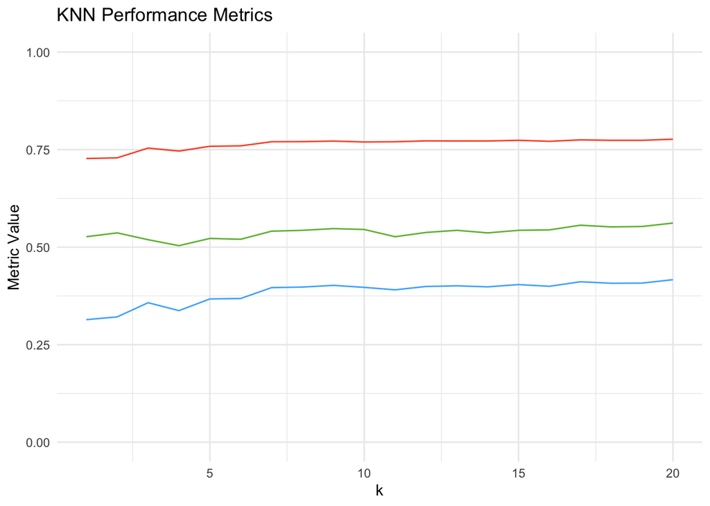

```r
ggplot(results, aes(x = k)) +
  geom_line(aes(y = Accuracy), color = "#FF5733") +
  geom_line(aes(y = Kappa), color = "#4CB3FE") +
  geom_line(aes(y = Sensitivity), color = "#6CBB3C") +
  labs(
    title = "KNN Performance Metrics",
    x = "k",
    y = "Metric Value"
  ) +
  theme_minimal() +
  scale_y_continuous(limits = c(0, 1))
```

```r
churn_col <- which(colnames(cust_scaled_train) == "Churn")
prediction_knn <- knn(train = cust_scaled_train[,-churn_col],
                      test = cust_scaled_test[,-churn_col],
                      cl = cust_scaled_train[,churn_col],
                      k = 7)
summary(prediction_knn)
```

```
##    0    1
## 2630  886
```

```r
confusionMatrix(as.factor(prediction_knn), as.factor(cust_scaled_test$Churn), positive = "1")
```

```
## Confusion Matrix and Statistics
##
##           Reference
## Prediction    0    1
##          0 2211  419
##          1  390  496
##
##                Accuracy : 0.7699
##                  95% CI : (0.7556, 0.7837)
##     No Information Rate : 0.7398
##     P-Value [Acc > NIR] : 2.015e-05
##
##                   Kappa : 0.3962
##
##  Mcnemar's Test P-Value : 0.3249
##
##             Sensitivity : 0.5421
##             Specificity : 0.8501
##          Pos Pred Value : 0.5598
##          Neg Pred Value : 0.8407
##              Prevalence : 0.2602
##          Detection Rate : 0.1411
##    Detection Prevalence : 0.2520
##       Balanced Accuracy : 0.6961
##
##        'Positive' Class : 1
##
```

**SVM:**

```r
try_kernels <- function(kernel_name) {
  model <- ksvm(as.factor(Churn) ~ ., data = cust_scaled_train, kernel = kernel_name)
  predictions <- predict(model, cust_scaled_test)
  cm <- confusionMatrix(as.factor(predictions), as.factor(cust_scaled_test$Churn), positive = "1")

  accuracy <- cm$overall["Accuracy"]
  kappa <- cm$overall["Kappa"]
  sensitivity <- cm$byClass["Sensitivity"]

  # Return all metrics
  return(c(accuracy = accuracy, kappa = kappa, sensitivity = sensitivity))
}


kernels <- c("vanilladot", "polydot", "rbfdot", "tanhdot", "anovadot", "laplacedot", "besseldot", "splinedot")
data.frame(sapply(kernels, try_kernels))
```

```
##                         vanilladot   polydot    rbfdot   tanhdot  anovadot
## accuracy.Accuracy        0.7980660 0.7980660 0.7997725 0.6814562 0.7986348
## kappa.Kappa              0.4550758 0.4550758 0.4381768 0.1865076 0.4279798
## sensitivity.Sensitivity  0.5540984 0.5540984 0.5005464 0.4142077 0.4808743
##                         laplacedot  besseldot splinedot
## accuracy.Accuracy        0.7935154  0.5196246 0.7485779
## kappa.Kappa              0.4051402 -0.2410397 0.1854264
## sensitivity.Sensitivity  0.4513661  0.0852459 0.2109290
```

```r
svm <- ksvm(as.factor(Churn) ~ ., data = cust_scaled_train,
                          kernel = "polydot")
svm_prediction <- predict(svm, cust_scaled_test)
confusionMatrix(as.factor(svm_prediction),
                as.factor(cust_scaled_test$Churn),
                positive="1")
```

```
## Confusion Matrix and Statistics
##
##           Reference
## Prediction    0    1
##          0 2299  408
##          1  302  507
##
##                Accuracy : 0.7981
##                  95% CI : (0.7844, 0.8112)
##     No Information Rate : 0.7398
##     P-Value [Acc > NIR] : 3.436e-16
##
##                   Kappa : 0.4551
##
##  Mcnemar's Test P-Value : 8.128e-05
##
##             Sensitivity : 0.5541
##             Specificity : 0.8839
##          Pos Pred Value : 0.6267
##          Neg Pred Value : 0.8493
##              Prevalence : 0.2602
##          Detection Rate : 0.1442
##    Detection Prevalence : 0.2301
##       Balanced Accuracy : 0.7190
##
##        'Positive' Class : 1
##
```

**Decision Tree:**

[figure not shown]

```r
dt <- C5.0(as.factor(Churn) ~ ., data = cust_train)
plot(dt)
```

```r
dt_prediction <- predict(dt, newdata = cust_test)

confusionMatrix(as.factor(dt_prediction),
                as.factor(cust_test$Churn),
                positive="1")
```

```
## Confusion Matrix and Statistics
##
##           Reference
## Prediction    0    1
##          0 2342  477
##          1  259  438
##
##                Accuracy : 0.7907
##                  95% CI : (0.7768, 0.804)
##     No Information Rate : 0.7398
##     P-Value [Acc > NIR] : 1.115e-12
##
##                   Kappa : 0.4108
##
##  Mcnemar's Test P-Value : 1.257e-15
##
##             Sensitivity : 0.4787
##             Specificity : 0.9004
##          Pos Pred Value : 0.6284
##          Neg Pred Value : 0.8308
##              Prevalence : 0.2602
##          Detection Rate : 0.1246
##    Detection Prevalence : 0.1982
##       Balanced Accuracy : 0.6896
##
##        'Positive' Class : 1
##
```

[figure not shown]

```r
cost_matrix <- matrix(c(0, 2,
                        1, 0),
                      nrow = 2,
                      byrow = TRUE)
rownames(cost_matrix) <- colnames(cost_matrix) <- c("0", "1")


dt2 <- C5.0(as.factor(Churn) ~ ., data = cust_train, costs = cost_matrix)
plot(dt2)
```

```r
dt2_prediction <- predict(dt, newdata = cust_test)

confusionMatrix(as.factor(dt2_prediction),
                as.factor(cust_test$Churn),
                positive="1")
```

```
## Confusion Matrix and Statistics
##
##           Reference
## Prediction    0    1
##          0 2342  477
##          1  259  438
##
##                Accuracy : 0.7907
##                  95% CI : (0.7768, 0.804)
##     No Information Rate : 0.7398
##     P-Value [Acc > NIR] : 1.115e-12
##
##                   Kappa : 0.4108
##
##  Mcnemar's Test P-Value : 1.257e-15
##
##             Sensitivity : 0.4787
##             Specificity : 0.9004
##          Pos Pred Value : 0.6284
##          Neg Pred Value : 0.8308
##              Prevalence : 0.2602
##          Detection Rate : 0.1246
##    Detection Prevalence : 0.1982
##       Balanced Accuracy : 0.6896
##
##        'Positive' Class : 1
##
```

**Random Forest:**

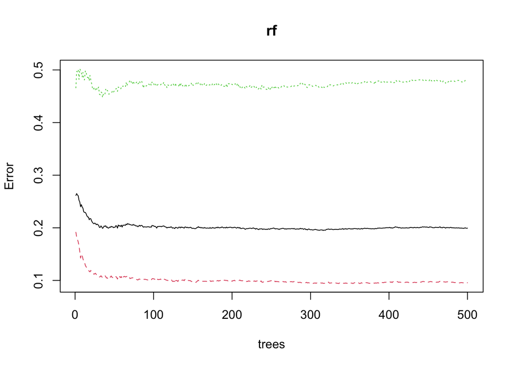

```r
set.seed(666)
rf <- randomForest(as.factor(Churn) ~ ., data = cust_train)
plot(rf)
```

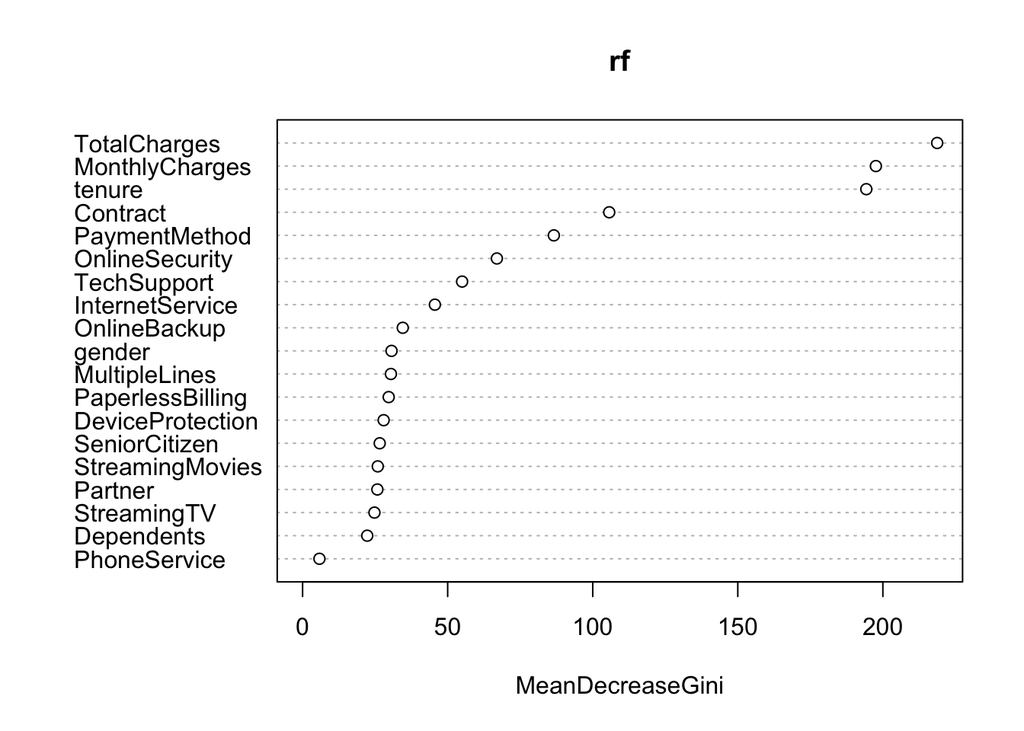

```r
randomForest::varImpPlot(rf)
```

```r
rf_prediction <- predict(rf, newdata = cust_test)

confusionMatrix(as.factor(rf_prediction),
                as.factor(cust_test$Churn),
                positive="1")
```

```
## Confusion Matrix and Statistics
##
##           Reference
## Prediction    0    1
##          0 2324  459
##          1  277  456
##
##                Accuracy : 0.7907
##                  95% CI : (0.7768, 0.804)
##     No Information Rate : 0.7398
##     P-Value [Acc > NIR] : 1.115e-12
##
##                   Kappa : 0.4189
##
##  Mcnemar's Test P-Value : 2.528e-11
##
##             Sensitivity : 0.4984
##             Specificity : 0.8935
##          Pos Pred Value : 0.6221
##          Neg Pred Value : 0.8351
##              Prevalence : 0.2602
##          Detection Rate : 0.1297
##    Detection Prevalence : 0.2085
##       Balanced Accuracy : 0.6959
##
##        'Positive' Class : 1
##
```

### Gathering all the predictions:

```r
# Renaming the original target variable from the test set:
response <- cust_test$Churn

all_predictions <- data.frame(
                              binary_prediction_lr,
                              prediction_knn,
                              svm_prediction,
                              dt2_prediction,
                              rf_prediction,
                              response)

str(all_predictions)
```

```
## 'data.frame':    3516 obs. of  6 variables:
##  $ binary_prediction_lr: num  1 1 0 0 0 0 0 0 0 1 ...
##  $ prediction_knn      : Factor w/ 2 levels "0","1": 2 2 1 1 1 1 1 1 1 1 ...
##  $ svm_prediction      : Factor w/ 2 levels "0","1": 2 2 1 1 1 1 1 1 1 2 ...
##  $ dt2_prediction      : Factor w/ 2 levels "0","1": 2 2 1 1 1 1 1 1 1 2 ...
##  $ rf_prediction       : Factor w/ 2 levels "0","1": 2 2 1 1 1 1 1 1 1 2 ...
##  $ response            : num  1 0 1 0 0 0 0 1 0 1 ...
```

```r
all_predictions$binary_prediction_lr <- as.factor(all_predictions$binary_prediction_lr)
all_predictions$response <- as.factor(all_predictions$response)
```

```r
test_rate <- 0.3
set.seed(666)

test_prediction_rows <- sample(1:nrow(all_predictions), test_rate*nrow(all_predictions))
train_predictions <- all_predictions[test_prediction_rows, ]
test_predictions <- all_predictions[-test_prediction_rows, ]
```

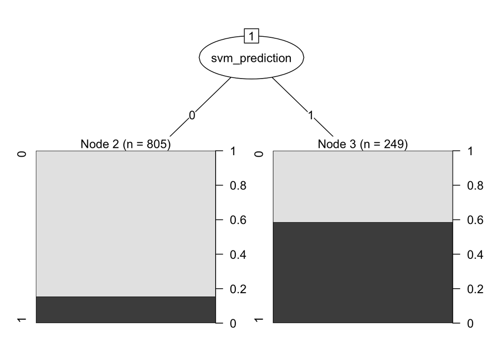

```r
model <- C5.0(as.factor(response) ~ ., data = train_predictions)
plot(model)
```

```r
predictions <- predict(model, newdata = test_predictions)

confusionMatrix <- table(predictions, test_predictions$response)
print(confusionMatrix)
```

```
##
## predictions    0    1
##           0 1618  284
##           1  199  361
```

```r
cost_matrix_prediction <- matrix(c(0, 2,
                                  1, 0),
                                  nrow = 2,
                                  byrow = TRUE)
rownames(cost_matrix) <- colnames(cost_matrix) <- c("0", "1")

model2 <- C5.0(as.factor(response) ~ ., data = train_predictions, costs = cost_matrix_prediction)
```

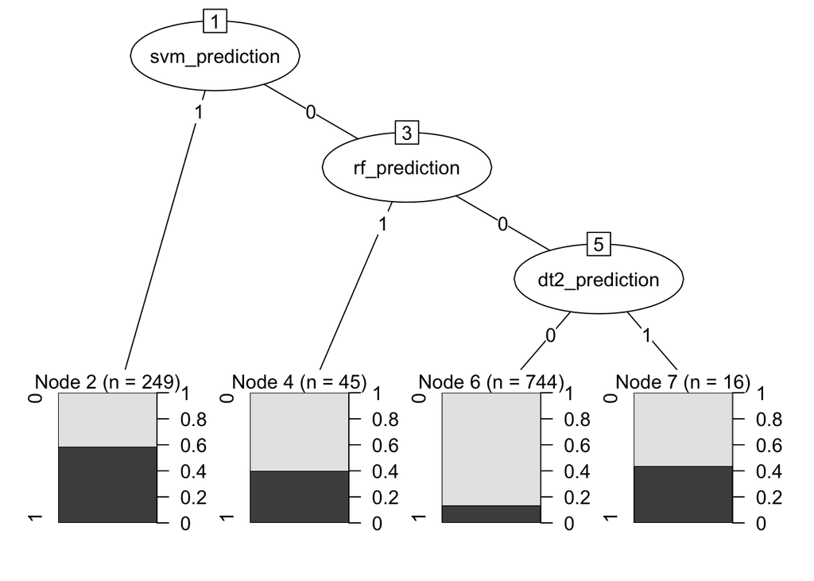

```r
plot(model2)
```

```r
predictions2 <- predict(model2, newdata = test_predictions)

confusionMatrix(as.factor(predictions2),
                as.factor(test_predictions$response),
                positive="1")
```

```
## Confusion Matrix and Statistics
##
##           Reference
## Prediction    0    1
##          0 1547  231
##          1  270  414
##
##                Accuracy : 0.7965
##                  95% CI : (0.7801, 0.8123)
##     No Information Rate : 0.738
##     P-Value [Acc > NIR] : 7.287e-12
##
##                   Kappa : 0.4838
##
##  Mcnemar's Test P-Value : 0.08956
##
##             Sensitivity : 0.6419
##             Specificity : 0.8514
##          Pos Pred Value : 0.6053
##          Neg Pred Value : 0.8701
##              Prevalence : 0.2620
##          Detection Rate : 0.1682
##    Detection Prevalence : 0.2778
##       Balanced Accuracy : 0.7466
##
##        'Positive' Class : 1
##
```